# R-Packages for Gaussian Process Regression

Afra Kilic, Supervisor: dr. ir. Joris Mulder

2023-03-31

Gaussian Process (GP) regression and Generalized Additive Models (GAMs) are both popular methods used in statistical modeling and machine learning for regression tasks. This work aims to compare available R packages to fit GP regression with each other and also with GAM. In the first part, the following R functions will be compared in terms of computation time, quantification of degree of non-linearity, posterior uncertainty and testing multiple predictors (i.e., multiple $X_{i}$);

- `gam` from `"mgcv"`
- `brm` from `"brms"`
- `cvek` from `"CVEK"`
- `gpr` from `"GPFDA"`
- `gausspr` from `"kernlab"`
- `GauPro` from `"GauPro"`

**The more detailed information regarding each package can be found in the package documentations, this work is only focused on the GP regression function in each package.**

In the second part, a real data example will be presented to compare GP regression with GAM and GLM by testing the hypothesis “the sharing of fake news is largely driven by low conscientiousness conservatives” from the study by Lawson and Kakkar (2021).

### summary

You can see the summary of the properties that the packages have in below:

```r
sum <- matrix(c(rep(NA, 24)), ncol = 6, nrow = 4)
colnames(sum) <- c("gam", "brm", "cvek", "gpr", "gausspr", "GauPro")
rownames(sum) <- c("degre of non-linearity", "posterior uncertainity", "testing", "testing multiple predictors")
sum[, 1] <- c("+", "+", "+", "+")
sum[, 2] <- c("+", "+", "+", "+")
sum[, 3] <- c("+", "-", "+", "+")
sum[, 4] <- c("+", "+", "-", "-")
sum[, 5] <- c("+", "+", "-", "-")
sum[, 6] <- c("-", "+", "-", "-")


knitr::kable(sum)
```

|  | gam | brm | cvek | gpr | gausspr | GauPro |
| --- | --- | --- | --- | --- | --- | --- |
| degre of non-linearity | + | + | + | + | + | - |
| posterior uncertainity | + | + | - | + | + | + |
| testing | + | + | + | - | - | - |
| testing multiple predictors | + | + | + | - | - | - |

### Generalized Additive Models (GAMs)

GAMs are a type of regression model that allow for flexible, non-linear relationships between the predictor variables and the response variable. GAMs accomplish this by modeling the response variable as a sum of smooth functions of the predictor variables, rather than a linear combination. This allows for more complex and nuanced relationships to be captured, which can be particularly useful when the true relationship between variables is not well understood or linear.

A generalized additive model for a response variable **$Y$**, modeled as a function of predictor variables **$X_{1}, X_{2}, ..., X_{n}$** can be expressed as:

$$g(E(Y)) = \beta_{0} + f_{1}(X_{1}) + f_{2}(X_{2}) + ... + f_{p}(X_{n}) + \epsilon$$
where **$f_{i}$** are smooth, non-linear functions of the predictor variables **$X_{i}$**, and **$\epsilon$** is a random error term. The functions **$f_{i}$** can be modeled using a variety of smoothing methods, such as splines, kernel methods, or generalized cross-validation.

### Gaussian Process (GP) Regression

On the other hand, Gaussian Process regression is a probabilistic regression model that is based on the assumption that the response variable follows a Gaussian distribution. GP regression can be seen as a generalization of linear regression, as it allows for non-linear relationships between the predictor variables and the response variable as well. However, rather than modeling the response variable as a sum of smooth functions of the predictor variables, GP regression models the response variable as a distribution over functions. This allows for greater flexibility in modeling complex relationships and also provides a measure of uncertainty in the predictions. The regression function modeled by a multivariate Guassian can be expressed as:

$$P(f|X) = N(f|\mu, K)$$

where $X=[x_{1}, ..., x_{n}], f =[f(x_{1}), ..., f(x_{n})], \mu = [m(x_{1}, ..., m(x_{n}))]$, and $K_{ij} = k(x_{i}, x_{j})$. $X$ are observed data points, $m$ represents the mean function, and $k$ represent a positive definite kernel function, which is Radial Basis Function Kernel in this work. Notice that with no observation, the mean function is default to be $m(X) = 0$ given that the data is often normalized to a zero mean. The GP model is a distribution over functions and $K$ defines the shape (smoothness) of this distribution. In particular, if the points $x_{i}$ and $x_{j}$ are considered similar by the kernel, then the function outputs of them, $f(x_{i})$ and $f(x_{j})$ are expected to be similar. RBF kernel can be expressed as:

$$k(x_{i}, x_{j}) = exp(- \frac{||x_{i}, x_{j}||^2} {2l^2})$$
where $l$ is a free positive parameter, also called $length$ parameter. Higher values of $l$ leads to smoother curves whereas lower values leads to more wiggly curves.

One of the key differences between GAMs and GP regression is their underlying assumptions about the nature of the relationships between variables. GAMs assume that the relationships are smooth and can be represented by a sum of smooth functions, while GP regression assumes that the relationships are continuous and can be represented by a distribution over functions. Additionally, GAMs are typically simpler to implement and interpret, while GP regression can be computationally intensive and requires more expertise to use effectively. Ultimately, the choice between GAMs and GP regression will depend on the specific nature of the data and the modeling task at hand.

## Part-I: Package Summaries & One-Predictor Model Application

In this part, the summary of each package will be given and the function of interest of each package will be used to fit the following model with non-linear relation between one-predictor and the outcome;

$$y = 0.5\frac{1}{\sigma\sqrt{2\pi}}e^{-\frac{1}{2}(\frac{x-\mu}{\sigma})^{2}} \times x + \epsilon, \qquad \epsilon \sim {\sf N}(0, 0.1)$$
First, the required packages have to be loaded. You can access to the overview of the packages on CRAN.

```r
library(mgcv)
library(brms)
library(kernlab)
library(GPFDA)
library(CVEK)
library(gam)
library(GauPro)
```

### Data Generation

```r
#Data Generation
set.seed(123)
n <- 250
xobs <- sort(runif(n,min=-3,max=3))
mu = rep(0,length(xobs))
sigma2 <- .1**2
error <- rnorm(n,sd=sqrt(sigma2))
yobs <- .5*dnorm(xobs)*xobs + error
data = as.data.frame(cbind(yobs, xobs))

#splitting into train and test data
sample <- sample(c(TRUE, FALSE), nrow(data), replace=TRUE, prob=c(0.8,0.2))
train <- data[sample,]
test <- data[!sample,]
```

```r
#LM fit

start_time_lm1 <- Sys.time()
fit_lm1 <- lm(yobs~ xobs, data = train)
end_time_lm1 <- Sys.time()
computation_time_lm1 <- end_time_lm1 - start_time_lm1
cat("Computation time LM:", computation_time_lm1, "minutes")
```

```
#> Computation time LM: 0.0169611 minutes
```

```r
summary(fit_lm1)
```

```
#>
#> Call:
#> lm(formula = yobs ~ xobs, data = train)
#>
#> Residuals:
#>      Min       1Q   Median       3Q      Max
#> -0.30656 -0.09389 -0.01349  0.09685  0.32025
#>
#> Coefficients:
#>              Estimate Std. Error t value Pr(>|t|)
#> (Intercept) -0.007681   0.008412  -0.913    0.362
#> xobs         0.032163   0.005097   6.311  1.7e-09 ***
#> ---
#> Signif. codes:  0 '***' 0.001 '**' 0.01 '*' 0.05 '.' 0.1 ' ' 1
#>
#> Residual standard error: 0.1207 on 204 degrees of freedom
#> Multiple R-squared:  0.1633, Adjusted R-squared:  0.1592
#> F-statistic: 39.82 on 1 and 204 DF,  p-value: 1.699e-09
```

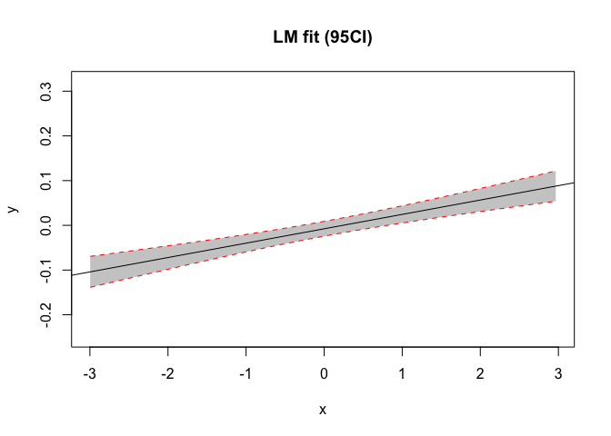

```r
#Plot the 95CI
df <- data.frame(x = train$xobs,
                 y = train$yobs)
mod <- lm(y ~ x, data = df)
# predicts + interval
newx <- seq(min(df$x), max(df$x), length.out=100)
preds <- predict(mod, newdata = data.frame(x=newx),
                 interval = 'confidence')
# plot
plot(y ~ x, data = df, type = 'n', main = "LM fit (95CI)")
# add fill
polygon(c(rev(newx), newx), c(rev(preds[ ,3]), preds[ ,2]), col = 'grey80', border = NA)
# model
abline(mod)
# intervals
lines(newx, preds[ ,3], lty = 'dashed', col = 'red')
lines(newx, preds[ ,2], lty = 'dashed', col = 'red')
```

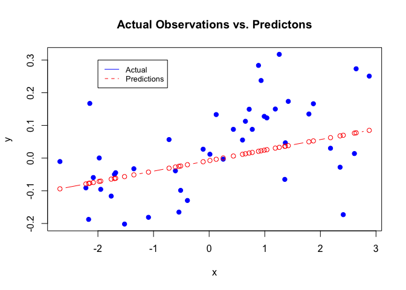

```r
#Testing the model
pred_lm1 <- predict(fit_lm1, newdata = test)

plot(test$xobs, test$yobs, main = "Actual Observations vs. Predictons",
     xlab = "x", ylab = "y", col = "blue", pch = 19)
points(test$xobs, pred_lm1, col = "red", type = "b")
legend(-2, 0.3, legend=c("Actual", "Predictions"), col = c("blue", "red"), lty=1:2, cex=0.8)
```

### mgcv

The function of interest, `gam`, fits generalized additive models, including quadratically penalized GLMs and other models estimated by a quadratically penalized likelihood approach. The smoothness of model terms is estimated during fitting (e.g. using AIC/BIC), and confidence/credible intervals are available for any predicted quantity. Smooth terms are represented using penalized regression splines or similar smoothers, and multi-dimensional smooths are available using penalized thin plate regression splines or tensor product splines. Linear functionals of smooths can also be included in models.

```r
start_time_gam1 <- Sys.time()
fit_gam1 <- mgcv::gam(yobs~ s(xobs), family='gaussian')
end_time_gam1 <- Sys.time()
computation_time_gam1 <- end_time_gam1 - start_time_gam1
cat("Computation time GAM:", computation_time_gam1, "minutes")
```

```
#> Computation time GAM: 0.154942 minutes
```

```r
summary(fit_gam1)
```

```
#>
#> Family: gaussian
#> Link function: identity
#>
#> Formula:
#> yobs ~ s(xobs)
#>
#> Parametric coefficients:
#>              Estimate Std. Error t value Pr(>|t|)
#> (Intercept) 0.0002135  0.0064177   0.033    0.973
#>
#> Approximate significance of smooth terms:
#>           edf Ref.df     F p-value
#> s(xobs) 5.911   7.08 25.24  <2e-16 ***
#> ---
#> Signif. codes:  0 '***' 0.001 '**' 0.01 '*' 0.05 '.' 0.1 ' ' 1
#>
#> R-sq.(adj) =  0.419   Deviance explained = 43.3%
#> GCV = 0.01059  Scale est. = 0.010297  n = 250
```

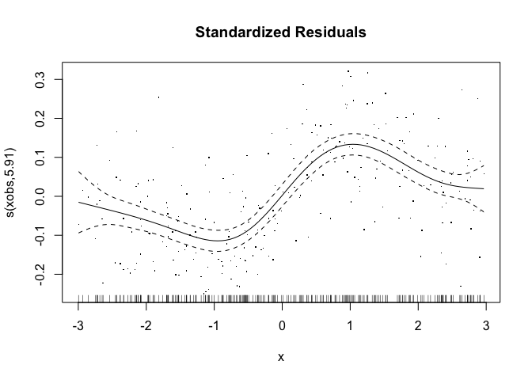

```r
plot(fit_gam1,pages=1,residuals=TRUE, main = "Standardized Residuals", xlab = "x")  ## show partial residuals
```

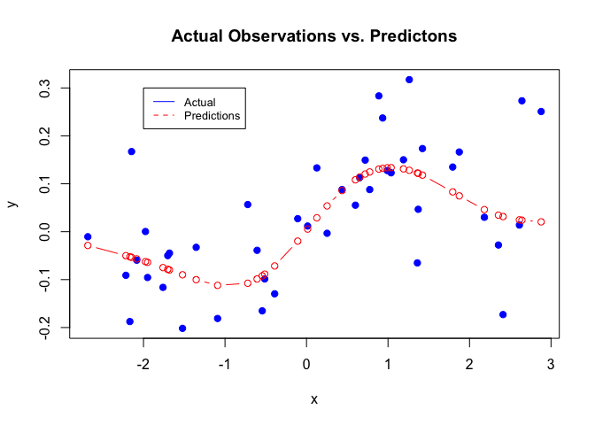

```r
#Testing the model
pred_gam1 <- predict(fit_gam1, newdata = test)


plot(test$xobs, test$yobs, main = "Actual Observations vs. Predictons",
     xlab = "x", ylab = "y", col = "blue", pch = 19)
points(test$xobs, pred_gam1, col = "red", type = "b")
legend(-2, 0.3, legend=c("Actual", "Predictions"), col = c("blue", "red"), lty=1:2, cex=0.8)
```

- The output is separated into `parametric` and `smooth` (i.e. non-parametric) parts. In this case, the only `parametric` component is the intercept as we added smooth term to $x$ variable. For both estimate types, the output includes p-value. Normally, degrees of freedom refers is equal to the number of features/terms in the model. However, p-values for `smooth` terms are based on effective degrees of freedom (`edf`). As in typical OLS, we are still trying to minimize the residual sums of squares, but in this case penalty for “wiggliness” have to be taken into consideration. So, the default p-value for the `smooth` term test is based on `edf` and the rank $r$ of the covariance matrix for the coefficients for a particular smooth. Conceptually, p-value is associated with the $F(r, n - edf)$. We cannot evaluate the p-values for `smooth` terms straightforwardly as in the `parametric` component (i.e., $p < 0.05$). But, it is still assumed that if the p-value for a `smooth` terms is very close to zero, then it may be concluded that there is a significant effect of the predictor on the outcome.
- The `edf` is a summary statistic of GAM and it reﬂects the degree of non-linearity of a curve (Wood 2006). An `edf` equal to 1 is equivalent to a linear relationship, 1 < `edf` ≤ 2 is considered a weakly non- linear relationship, and `edf` > 2 implies a highly non- linear relationship (Stenseth et al. 2006, Litzow and Ciannelli 2007, Zuur et al. 2009). As the `edf` increasingly exceeds 2, the degree of non- linearity progressively increases. In this case, `edf` is $5.9$ meaning that the relationship between $x$ and $y$ is highly non-linear.
- Another important metric in GAM output is generalized cross validation (GCV) score, an estimation of the mean square prediction error obtained through a leave-one-out cross validation process. This involves fitting the model to all observations except one, and then calculating the squared residual for predicting that omitted observation using the model. This process is repeated for all observations. However, the GCV score efficiently measures this concept without the need to fit all those models, and it also overcomes other issues. By default, the GCV score is minimized to determine the smooth’s specific nature. While the GCV score alone doesn’t provide much information, it can be used as a comparative measure similar to AIC for choosing among different models, with lower scores being preferable.
- Information on posterior uncertainty quantification for the model itself is also provided in the `gam` object. However, it does not provide uncertainty information for the predicted values.

### brms

The function of interest `brm` fits Bayesian generalized (non-)linear multivariate multilevel models using Stan for full Bayesian inference. It supports a wide range of distributions and link functions, including linear, robust linear, count data, survival, response times, ordinal, zero-inflated, hurdle, and self-defined mixture models in a multilevel context. Other modeling options include non-linear and smooth terms, auto-correlation structures, censored data, and meta-analytic standard errors. Prior specifications are flexible and model fit can be assessed and compared using posterior predictive checks and leave-one-out cross-validation.

```r
set.seed(123)
start_time_brms1 <- Sys.time()
fit_brms1 <- brms::brm(yobs ~ gp(xobs), data = train, chains = 2)
```

[output not shown]

```r
end_time_brms1 <- Sys.time()
computation_time_brms1 <- end_time_brms1 - start_time_brms1
cat("Computation time BRMS:", computation_time_brms1, "minutes")
```

```
#> Computation time BRMS: 25.75628 minutes
```

```r
summary(fit_brms1)
```

[output not shown]

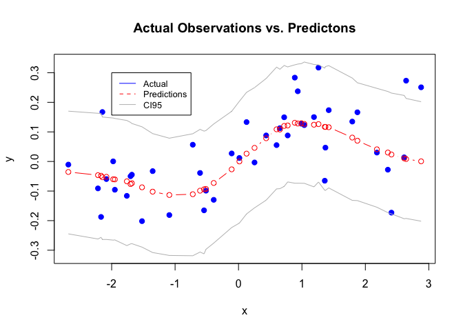

```r
#Testing the model
pred_brms1 <- predict(fit_brms1, newdata = test)
plot(test$xobs, test$yobs, main = "Actual Observations vs. Predictons",
     xlab = "x", ylab = "y", col = "blue", pch = 19, ylim=c(min(pred_brms1[,3]), max(pred_brms1[,4])))
points(test$xobs, pred_brms1[,1], col = "red", type = "b")
lines(test$xobs, pred_brms1[,3], col = "gray") #lower bound
lines(test$xobs, pred_brms1[,4], col = "gray")#upper bound
legend(-2, 0.3, legend=c("Actual", "Predictions", "CI95"), col = c("blue", "red", "gray"), lty=1:2, cex=0.8)
```

- In general, every parameter is summarized using the mean (`Estimate`) and the standard deviation (`Est.Error`) of the posterior distribution as well as two-sided 95% credible intervals (`l-95% CI` and `u-95% CI`) based on quantiles. If the parameter estimates are not in the 95% CI interval, then we can say that the evidence based on the data and applied model is not very strong and still insufficient by standard decision rules. In this case, every parameter estimate is located within the 95% CI interval. However, we should also check the last three values (`ESS_bulk`,`ESS_tail`, and `Rhat`) which provide information on how well the algorithm could estimate the posterior distribution of this parameter. If `Rhat` is considerably greater than 1, the algorithm has not yet converged and it is necessary to run more iterations and / or set stronger priors. In this case, `Rhat` is greater than 1, so the model did not converge. Thus, it is necessary to run more iterations or set stronger priors to achieve convergence.
- This package only support the exponentiated-quadratic kernel which is defines as $k(x_{i}, x_{j}) = sdgp^{2}exp(-||x_{i}-x_{j}||^{2}/(2lscale^{2}))$, where $||.||$ is Euclidean norm, $sdgp$ is a standard deviation parameter, and $lscale$ is the length scale parameter. `brm` object gives the parameter estimates in the “Gaussian Process Terms” section with 95CI. `lscale` estimates refers to “wiggliness” of the relationship so it can be considered as the quantification of degree of non-linearity.

To investigate and compare model fit, we can apply graphical posterior predictive checks, which make use of the bayesplot package on the backend.

```r
brms::pp_check(fit_brms1)
```

```
#> Using 10 posterior draws for ppc type 'dens_overlay' by default.
```

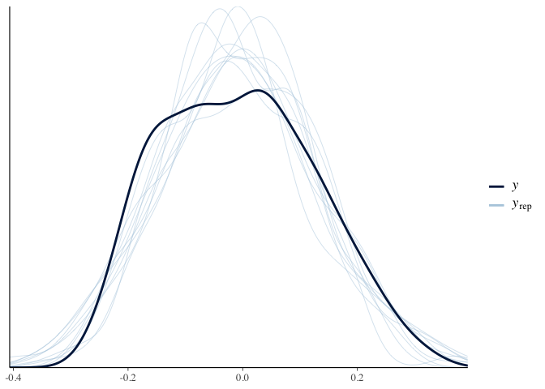

### CVEK

The function of interest `cvek` allows us to model joint nonlinear effect of multiple covariates. It provides hypothesis tests for main effects and interactions among features based on ensemble learning with kernel-ridge estimators. Hypothesis testing uses either the asymptotic or the bootstrap version of a generalized score test. The latter method allows us to deal with small sample sizes. The package offers a range of choices for kernel family, model selection criteria, ensembling method, and type of hypothesis test, making it a flexible and easy-to-use implementation of CVEK.

[See this document for the details of the hypothesis testing procedure using `cvek`](https://cran.r-project.org/web/packages/CVEK/vignettes/vignette.html).

```r
set.seed(123)
kern_par <- data.frame(method = c("linear", "rbf"), #model library specification
                       l = rep(1, 2), p = 1:2, stringsAsFactors = FALSE)
# define kernel library
kern_func_list <- CVEK::define_library(kern_par)

start_time_cvek1 <- Sys.time()
fit_CVEK1 <- CVEK::cvek(yobs ~  k(xobs) , kern_func_list = kern_func_list, data = train,
                       lambda = exp(seq(-3, 5)), test = "asymp")
end_time_cvek1 <- Sys.time()
computation_time_cvek1 <- end_time_cvek1 - start_time_cvek1
cat("Computation time CVEK:", computation_time_cvek1, "minutes")
```

```
#> Computation time CVEK: 5.65214 minutes
```

```r
fit_CVEK1$beta #Fixed effect estimate of x on y.
```

```
#>              [,1]
#> [1,] -0.002954157
```

```r
fit_CVEK1$lambda #The selected tuning parameter based on the estimated ensemble kernel matrix.
```

```
#> [1] 0.04978707
```

```r
fit_CVEK1$u_hat #A vector of weights of the kernels in the library.
```

```
#> [1] 0 1
```

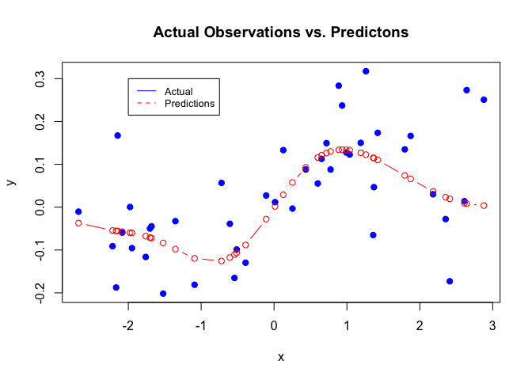

```r
#Testing the model
pred_CVEK1 <- predict(fit_CVEK1, newdata = test)

plot(test$xobs, test$yobs, main = "Actual Observations vs. Predictons",
     xlab = "x", ylab = "y", col = "blue", pch = 19)
points(test$xobs, pred_CVEK1, col = "red", type = "b")
legend(-2, 0.3, legend=c("Actual", "Predictions"), col = c("blue", "red"), lty=1:2, cex=0.8)
```

- $k()$ is specified as semi-parametric model with a model library including *linear* and *rbf* kernels with *l=1*. here, we include the non-linearity to the model with the *rbf* kernel. `fit_CVEK1$u_hat` shows us that the ensemble weight assigns 1 to the *rbf* kernel, meaning that the relationship between $x$ and $y$ is not linear.
- `fit_CVEK1$beta` shows the fixed effect estimates of the predictor on the outcome variable. In this case, the fixed effect of $x$ is estimated as a non-positive value. But the model also says that the relationship is not linear, so it is not very easy to comment on these estimates directly. Hypothesis testing procedure can be applied.
- `fit_CVEK1$lambda` refers to the selected tuning parameter based on the estimated kernel matrix. When `fit_CVEK1$lambda` equals to zero, then there is no penalty to the model which may refer that the relationship is linear. So this metric can also be seen as a quantification of non-linearity.
- However, posterior uncertainty quantification is a little bit unclear in this package.

### GPFDA

This package is for modelling functional data with multidimensional inputs, multivariate functional data, and non-separable and/or non-stationary covariance structure of function-valued processes. The function of interest `gpr` fits GP regression for a single or multiple independent outcomes.

- We specify the covariance matrix for `gpr` functin as `Cov = matern`. It has another positive parameter called $\nu$ besides on the length parameter $\sigma$ in *rbf* kernel. As goes to infinity, Matern covariance matrix converges to squared exponential covariance matrix. [(see this for more detail)](https://andrewcharlesjones.github.io/journal/matern-kernels.html).

```r
start_time_gpr1 <- Sys.time()
fit_gpr1 <- GPFDA::gpr(response=as.matrix(train$yobs), input = as.matrix(train$xobs), Cov = "matern", gamma = 2, trace = 4)
```

```
#>
#>  --------- Initialising ----------
#> iter:  -loglik:     matern.v     matern.w     vv
#>   0:    -167.33747: -6.06596 -0.381832 -4.53479
#>   4:    -169.40038: -5.25607 -0.180255 -4.54877
#>   8:    -169.53994: -5.01355 -0.547110 -4.57709
#>
#>      optimization finished.
```

```r
end_time_gpr1 <- Sys.time()
computation_time_gpr1 <- end_time_gpr1 - start_time_gpr1
cat("Computation time GPR:", computation_time_gpr1, "minutes")
```

```
#> Computation time GPR: 21.43059 minutes
```

```r
sapply(fit_gpr1$hyper, exp) #estimated parameters in log scale
```

```
#>    matern.v    matern.w          vv
#> 0.006647272 0.578562363 0.010284824
```

```r
fit_gpr1$var.hyper #estimation variance
```

```
#>     matern.v     matern.w           vv
#> 1.232934e-03 4.019565e-03 4.902414e-05
```

```r
summary(fit_gpr1)
```

```
#>                 Length Class  Mode
#> hyper               3  -none- list
#> var.hyper           3  -none- numeric
#> fitted.mean       206  -none- numeric
#> fitted.sd         206  -none- numeric
#> train.x           206  -none- numeric
#> train.y           206  -none- numeric
#> train.yOri        206  -none- numeric
#> train.DataOri     206  -none- numeric
#> idxSubset           0  -none- NULL
#> CovFun              1  -none- character
#> gamma               1  -none- numeric
#> nu                  1  -none- numeric
#> Q               42436  -none- numeric
#> inv             42436  -none- numeric
#> mu                  1  -none- numeric
#> meanModel           1  -none- numeric
#> meanLinearModel     0  -none- NULL
#> conv                1  -none- numeric
#> hyper0              3  -none- numeric
```

```
#> Predicted values not found, ploting fitted values
```

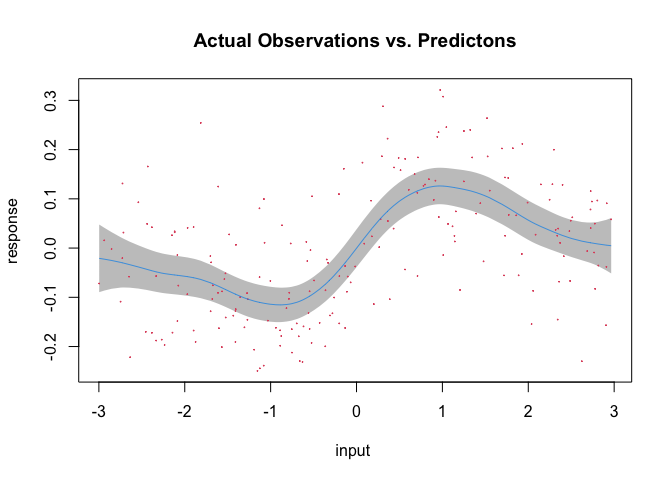

```r
plot(fit_gpr1, main = "Actual Observations vs. Predictons")
```

```r
#Testing the model
pred_gpr1 <- GPFDA::gprPredict(fit_gpr1, inputNew = test[, c(2)])
vignette("gpr_ex1", package = "GPFDA")
```

```
#> starting httpd help server ... done
```

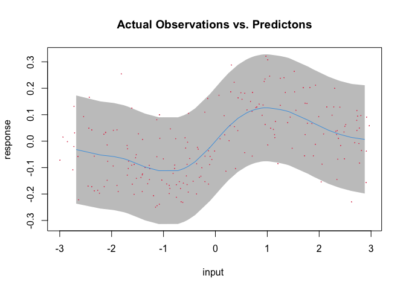

```r
plot(pred_gpr1,main = "Actual Observations vs. Predictons")
```

- `gpr` function estimates the hyperparameters of the covariance matrix. So it returns two hyperparameter estimation as `matern.w` and `matern.v` in log scale. `vv` stands for Gaussian white noise. You can also see the variance of the paramater estimates. For matern covariance matrix, it is not clear in the package documentation which parameter estimation to which parameter of matern covariance matrix. $\rho$ parameter of matern covariance matrix shows the smoothness and it is very similar to $l$ parameter of *rbf*. So this function normally quantifies the non-linearity but it is not clear in the matern case.
- Information on posterior uncertainty quantification is also provided in the `gpr` object.

### kernlab

This package includes Kernel-based machine learning methods for classification, regression, clustering, novelty detection, quantile regression and dimensionality reduction. The function of interest `gausspr` fits implements for both regression and classification.LaPlace approximation is used for the parameter estimation in GP for classification, which makes it computationally more efficient.

```r
set.seed(123)
start_time_gausspr1 <- Sys.time()
fit_gausspr1 <- gausspr(train$xobs, train$yobs, kernel = "rbfdot", variance.model = TRUE)
```

```
#> Using automatic sigma estimation (sigest) for RBF or laplace kernel
```

```r
end_time_gausspr1 <- Sys.time()
computation_time_gausspr1 <- end_time_gausspr1 - start_time_gausspr1
cat("Computation time GAUSSPR:", computation_time_gausspr1, "minutes")
```

```
#> Computation time GAUSSPR: 0.06511998 minutes
```

```r
fit_gausspr1
```

```
#> Gaussian Processes object of class "gausspr"
#> Problem type: regression
#>
#> Gaussian Radial Basis kernel function.
#>  Hyperparameter : sigma =  12.9001565365577
#>
#> Number of training instances learned : 206
#> Train error : 0.559131842
```

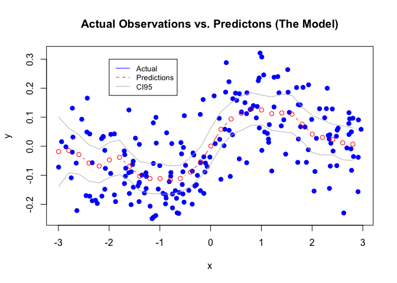

```r
#Posterior Distribution of the model
plot(train$xobs,train$yobs, main = "Actual Observations vs. Predictons (The Model)",
     xlab = "x", ylab = "y", col = "blue", pch = 19)
xtest <- seq(min(train$xobs),max(train$xobs),0.2)
lines(xtest, predict(fit_gausspr1, xtest) , col = "red", type = "b")
lines(xtest,
predict(fit_gausspr1, xtest)+2*predict(fit_gausspr1,xtest, type="sdeviation"),
                                         col="gray")
lines(xtest,
      predict(fit_gausspr1, xtest)-2*predict(fit_gausspr1,xtest, type="sdeviation"),
      col="gray")
legend(-2, 0.3, legend=c("Actual", "Predictions", "CI95"), col = c("blue", "red", "gray"), lty=1:2, cex=0.8)
```

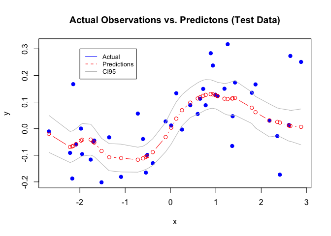

```r
#Posterior Distribution for the test data.
plot(test$xobs, test$yobs, main = "Actual Observations vs. Predictons (Test Data)",
     xlab = "x", ylab = "y", col = "blue", pch = 19)
lines(test$xobs, predict(fit_gausspr1, newdata = test$xobs), col = "red", type = "b")
lines(test$xobs, #95CI upper bound
      predict(fit_gausspr1, newdata = test$xobs) +
        2*predict(fit_gausspr1, newdata = test$xobs, type = "sdeviation"),
      col = "gray")
lines(test$xobs,  #95CI lower bound
      predict(fit_gausspr1, newdata = test$xobs) -
        2*predict(fit_gausspr1, newdata = test$xobs, type = "sdeviation"),
      col = "gray")
legend(-2, 0.3, legend=c("Actual", "Predictions", "CI95"), col = c("blue", "red", "gray"), lty=1:2, cex=0.8)
```

- `gausspr` object returns “training error” and the relevant hyperparameter estimate of the model. In our case it is $l$ parameter of RBF kernel which defines the smoothness of the distribution. As $l$ parameter defines smoothness of the relationship, this function also quantifies the degree of non-linearity.
- We can also calculate the mean and the covariance matrix by using estimation to calculate the CI95 manually as following;

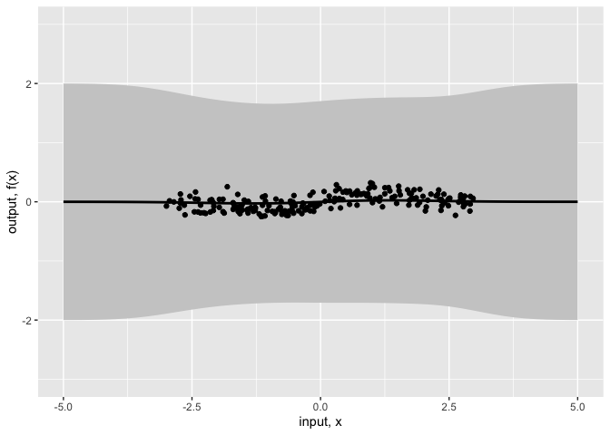

```r
x_predict <- seq(-5,5,len=50)

#Radial Basis Kernel
SE <- function(Xi,Xj, l=1) exp(-0.5 * (Xi - Xj) ^ 2 / l ^ 2)
cov <- function(X, Y) outer(X, Y, SE)

#Mean and Covariance Matrix
sigma <- fit_gausspr1@kernelf@kpar[[1]] #sigma estimated by the model
cov_xx_inv <- solve(cov(train$xobs, train$xobs) + sigma^2 * diag(1, length(train$xobs)))
Ef <- cov(x_predict, train$xobs) %*% cov_xx_inv %*% train$yobs
Cf <- cov(x_predict, x_predict) - cov(x_predict, train$xobs)  %*% cov_xx_inv %*% cov(train$xobs, x_predict)


#Posterior Distribution
require(ggplot2)
dat <- data.frame(x=x_predict, y=(Ef), ymin=(Ef-2*sqrt(diag(Cf))), ymax=(Ef+2*sqrt(diag(Cf))))
ggplot(dat) +
  geom_ribbon(aes(x=x,y=y, ymin=ymin, ymax=ymax), fill="grey80") + # Var
  geom_line(aes(x=x,y=y), size=1) + #MEAN
  geom_point(data=train,aes(x=xobs,y=yobs)) +  #OBSERVED DATA
  scale_y_continuous(lim=c(-3,3), name="output, f(x)") + xlab("input, x")
```

- This posterior distribution seems better but still it is too wide . Thus, the uncertainty quantification of the model seems not very clear in `kernlab`.

### GauPro

This packages was created to speed up the computer experiments by storing GP models as `R6` objects and updating theme with new data if it is needed. The function of interest `GauPro` fits Gaussian Process regression with an option to run parallel.

- The code is created using the `R6` class structure, so `$` operator is used to access object methods.

```r
set.seed(123)
start_time_gaupro1 <- Sys.time()
fit_gp1 <- GauPro::GauPro(train$xobs, train$yobs, parallel=FALSE)
end_time_gaupro1 <- Sys.time()
computation_time_gaupro1 <- end_time_gaupro1 - start_time_gaupro1
cat("Computation time GauPro:", computation_time_gaupro1, "minutes")
```

```
#> Computation time GauPro: 3.328957 minutes
```

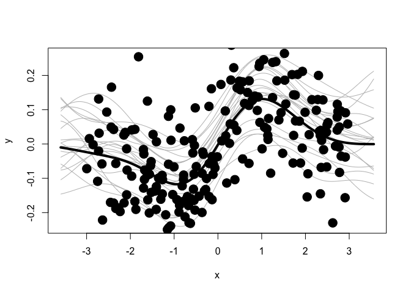

```r
#Distributions for the predictions
if (requireNamespace("MASS", quietly = TRUE)) {
  plot(fit_gp1)
}
```

```r
fit_gp1$param.est
```

```
#> [1] TRUE
```

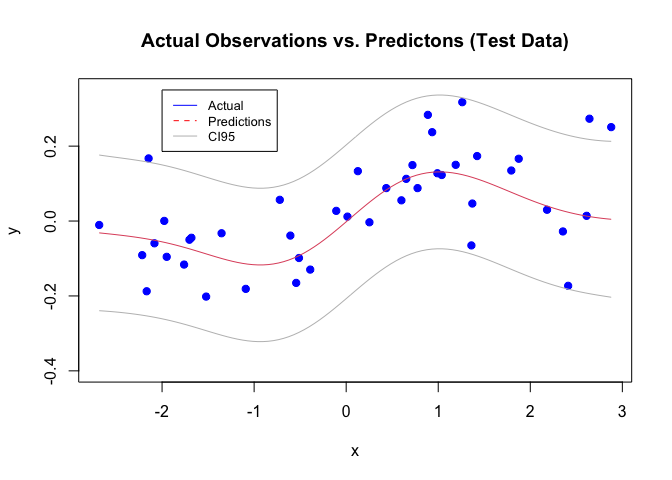

```r
#Testing the model

x <- test$xobs
y <- test$yobs

plot(x, y, main = "Actual Observations vs. Predictons (Test Data)",
     xlab = "x", ylab = "y", col = "blue", pch = 19, ylim = c(-.4, 0.35))
curve(fit_gp1$predict(x), add=T, col=2)
curve(fit_gp1$predict(x)+2*fit_gp1$predict(x, se=T)$se, add=T, col="gray") #95% CI for upper bound
curve(fit_gp1$predict(x)-2*fit_gp1$predict(x, se=T)$se, add=T, col="gray") #95% CI for lower bound
legend(-2, 0.35, legend=c("Actual", "Predictions", "CI95"), col = c("blue", "red", "gray"), lty=1:2, cex=0.8)
```

* GauPro gives posterior distribution for the predictions (*the above graph*) and the prediction error for the predicted values (*the below graph*). The gray lines give the approximate 95½ confidence interval.

## Part-II: Real Data Example

In this part, I will test the hypothesis from the study by Lawson and Kakkar (2021): “the sharing of fake news is largely driven by low conscientiousness conservatives”. The original study tested this hypothesis using linear fit, following that Simonsohn (2022) tested the same hypothesis with `gam` fit to illustrate the similarities and differences between linear and GAM simple slopes. The original data and the code is accessible [here](https://researchbox.org/746). *use this code: OVTJGP* .

I will also fit the same model using `glm`, `gam`, and `brm` to illustrate how gaussian process regression differs from `gam` and `glm`.

*The out outcome variable of the model of interest is categorical (i.e., 1 = sharing & 0 = not sharing), so the task is a classifcation task with a sample size of 23,928. Among all packages, there are two packages with gp classification: `brm` and `gausspr`. While `brm` is computationally more inefficient at relatively small sample sizes like in the simulation study in part-I, it is way more efficient than `gausspr` at large sample sizes. For this reason, `brm` function is determined to be used in real data example.*

```r
#Just Non-linear Interaction
#Simonsohn Data
setwd("~/Desktop")
data <- read.csv("dataa.csv")
```

### Model Fits

```r
#glm
start_time_glm <- Sys.time()
fit_glm <- glm(share~conservatism*c, data = data, family='binomial')
end_time_glm <- Sys.time()
computation_time_glm <- end_time_glm - start_time_glm
cat("Computation time GLM:", computation_time_glm, "minutes")
```

```
#> Computation time GLM: 0.08018684 minutes
```

```r
#gam
start_time_gam <- Sys.time()
fit_gam <- mgcv::gam(share~te(conservatism,c),data = data, family='binomial')
end_time_gam <- Sys.time()
computation_time_gam <- end_time_gam - start_time_gam
cat("Computation time GAM:", computation_time_gam, "minutes")
```

```
#> Computation time GAM: 26.94408 minutes
```

```r
#brms
start_time_brms <- Sys.time()
fit_brms <- brms::brm(share ~ gp(conservatism*c), data, chains = 2, family = bernoulli(), seed = 123) #family as bernoulli for binomial model
```

[output not shown]

```r
end_time_brms <- Sys.time()
computation_time_brms <- end_time_brms - start_time_brms
cat("Computation time BRMS:", computation_time_brms, "minutes")
```

```
#> Computation time BRMS: 24.74852 minutes
```

```r
summary(fit_brms)
```

```
#>  Family: bernoulli
#>   Links: mu = logit
#> Formula: share ~ gp(conservatism * c)
#>    Data: data (Number of observations: 23928)
#>   Draws: 2 chains, each with iter = 2000; warmup = 1000; thin = 1;
#>          total post-warmup draws = 2000
#>
#> Gaussian Process Terms:
#>                           Estimate Est.Error l-95% CI u-95% CI Rhat Bulk_ESS
#> sdgp(gpconservatismMUc)       1.14      0.08     0.99     1.31 1.00      434
#> lscale(gpconservatismMUc)     0.00      0.00     0.00     0.00 1.00      673
#>                           Tail_ESS
#> sdgp(gpconservatismMUc)        689
#> lscale(gpconservatismMUc)     1307
#>
#> Population-Level Effects:
#>           Estimate Est.Error l-95% CI u-95% CI Rhat Bulk_ESS Tail_ESS
#> Intercept    -0.91      0.10    -1.11    -0.71 1.02      132      363
#>
#> Draws were sampled using sampling(NUTS). For each parameter, Bulk_ESS
#> and Tail_ESS are effective sample size measures, and Rhat is the potential
#> scale reduction factor on split chains (at convergence, Rhat = 1).
```

- Looking at the summary of the `brm` object, we see that the `lscale` parameter estimation is zero. It means that the two point is almost entirely independent so the interaction effect is very wiggly (non-linear). But the model warns us also about the effective sample size. So this, model can be run with more iterations to have more reliable estimations.

### Predictions

```r
#PREDICTIONS

#Low vs high moderator
sdk=1
xpredict=1:7
z.low  <- mean(data$c) - sd(data$c)*sdk
z.high <- mean(data$c) + sd(data$c)*sdk

#probit (it's actually logit, legacy comments and variable names)
probit.y.high <-predict(fit_glm , newdata = data.frame(c=z.high,conservatism=xpredict),type='response')
probit.y.low  <-predict(fit_glm , newdata = data.frame(c=z.low,conservatism=xpredict), type='response')
```

```r
#gam.Spotlight
gam.y.high <-predict(fit_gam , newdata = data.frame(c=z.high, conservatism=xpredict),type='response')
gam.y.low  <-predict(fit_gam , newdata = data.frame(c=z.low,conservatism=xpredict), type='response')
```

```r
#brms prediction
brms.y.high <- predict(fit_brms, newdata = data.frame(c=z.high,conservatism=xpredict),type='response')
brms.y.low <- predict(fit_brms, newdata = data.frame(c=z.low,conservatism=xpredict),type='response')
```

### Bootstrap for both `glm` and `gam` simple slopes

```r
#Unique participant id to bootstrap by it
data <- subset(data, non_US_ip==0)
```

```r
# Function for quantiles to run through apply
    q025 <- function(x) quantile(x,.025)
    q975 <- function(x) quantile(x,.975)

  #Automatically name elements in list with name of the objects in the list
    #https://stackoverflow.com/questions/16951080/can-lists-be-created-that-name-themselves-based-on-input-object-names
    namedList <- function(...) {
      L <- list(...)
      snm <- sapply(substitute(list(...)),deparse)[-1]
      if (is.null(nm <- names(L))) nm <- snm
      if (any(nonames <- nm=="")) nm[nonames] <- snm[nonames]
      setNames(L,nm)
    }

  # BOTH (gam and lm) simple slopes for the bootstrap study
      both.simple.slope <- function(x,z,y,sdk=1,xpredict=1:7)
      {
      #Estimate gam model
       # g <- gam(y~s(x,k=4)+s(z,k=4)+ti(x,z),family='binomial')
        g <- mgcv::gam(y~te(x,z),family='binomial')
        m <- glm(y~x*z,family='binomial')

      #Low vs high moderator
        z.low  <- mean(z) - sd(z)*sdk
        z.high <- mean(z) + sd(z)*sdk

      #gam.Spotlight
        gam.y.high <-predict(g , newdata = data.frame(z=z.high,x=xpredict),type='response')
        gam.y.low  <-predict(g , newdata = data.frame(z=z.low,x=xpredict), type='response')

      #probit (it's actually logit, legacy comments and variable names)
         probit.y.high <-predict(m , newdata = data.frame(z=z.high,x=xpredict),type='response')
         probit.y.low  <-predict(m , newdata = data.frame(z=z.low,x=xpredict), type='response')


        return(namedList(gam.y.high , gam.y.low, probit.y.high, probit.y.low))
      }
```

```r
 # Bootstrap study

      set.seed(50)

    #Unique participant id to bootstrap by it
      participant.all <- unique(data$participant)

    #Smaller dataset with just the 3 variables of interest
      data.subset <- subset(data,select=c("share", "participant","c","conservatism"))

    #How many bootstraps
      btot=250

    #Empty tables with results from bootstrap
      gam.y.high.boot = gam.y.low.boot =
      probit.y.high.boot = probit.y.low.boot =
      matrix(nrow=btot,ncol=7)                  #empty matrix

    #Bootstrap loop
      for (bk in 1:btot){

      #Initiate empty dataframe
        data.boot <-data.frame(share=c(),c=c(),conservatism=c())

      #Draw participants IDs for this bootstrap
        participant.boot <- sample(participant.all,replace=TRUE)

      #Get their data
        for (k in 1:length(participant.boot)) {
          data.boot <-rbind(data.boot, subset(data.subset , participant==participant.boot[k]))
        }

      #
        s.boot <- both.simple.slope(x=data.boot$conservatism, z=data.boot$c, y=data.boot$share)
        gam.y.high.boot[bk,] <- s.boot$gam.y.high
        gam.y.low.boot[bk,] <- s.boot$gam.y.low
        probit.y.high.boot[bk,] <- s.boot$probit.y.high
        probit.y.low.boot[bk,] <- s.boot$probit.y.low
        cat("...",bk)
    }
```

[output not shown]

```r
      bootstrap.results<-namedList(gam.y.high.boot,    gam.y.low.boot,
                                   probit.y.high.boot, probit.y.low.boot)



    #Compute 2.5th and 97.5th percentils
      # GAM
        yh1.g.lb <- apply(bootstrap.results$gam.y.high.boot,2,q025)
        yh1.g.ub <- apply(bootstrap.results$gam.y.high.boot,2,q975)
        yh0.g.lb <- apply(bootstrap.results$gam.y.low.boot,2,q025)
        yh0.g.ub <- apply(bootstrap.results$gam.y.low.boot,2,q975)

      #Logit
        yh1.m.lb <- apply(bootstrap.results$probit.y.high.boot,2,q025)
        yh1.m.ub <- apply(bootstrap.results$probit.y.high.boot,2,q975)
        yh0.m.lb <- apply(bootstrap.results$probit.y.low.boot,2,q025)
        yh0.m.ub <- apply(bootstrap.results$probit.y.low.boot,2,q975)

#Combine into single vector
      #GAM CI
        ci1.g <- c(yh1.g.ub, rev(yh1.g.lb))  #Confidence interval for high moderator
        ci0.g <- c(yh0.g.ub, rev(yh0.g.lb))  #Confidence interval for low  moderator


      #LOGIT  CI
        ci1.m <- c(yh1.m.ub, rev(yh1.m.lb))
        ci0.m <- c(yh0.m.ub, rev(yh0.m.lb))
```

### Plots for `glm` and `gam`

Simonsohn shows how `gam` performs better at showing the non-linear interaction between conscientiousness and being conservative. As we can notice from the GAM simple slopes; On average less conscientious people are more likely to share fake news but conservatism increases this effect more than the `glm` graph shows. Also notice the inflection point in the high conscientiousness line (in red) in GAM simple slopes graph. In particular, if a person is neither liberal nor conservative, regardless of their conscientiousness level they tend to share fake news more or less in the same level. In sum, Simonsohn argues that the models allowing us to observe non-linear relationships can be better because social phenomenons can be non-linear despite we commonly expect them to be linear.

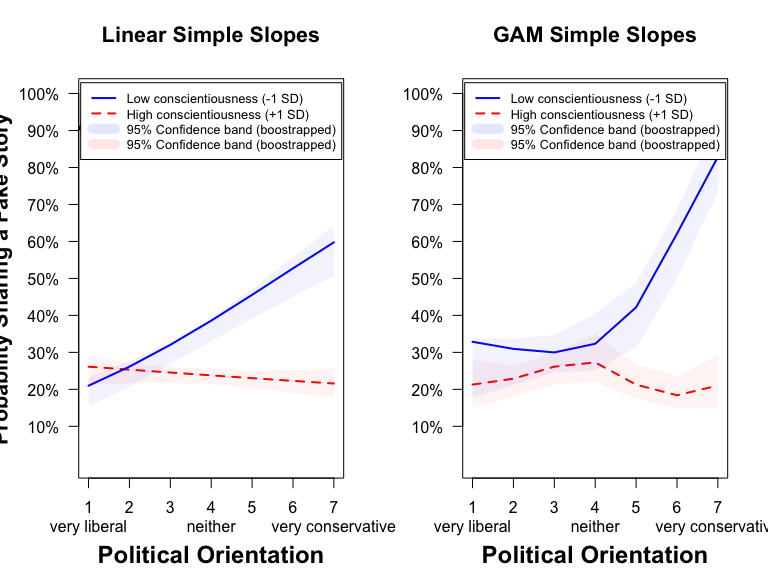

```r
    # Margins
      par(mfrow=c(1,2))

    #Linear simple slopes
      #LINES
        plot  (1:7, probit.y.high,type='l',col='red',ylim=c(0,1),lty=2,lwd=2,ylab='',las=1,yaxt='n',xaxt='n',xlab='')
        points(1:7 ,probit.y.low,type='l',col='blue',lwd=2)

      #band
        polygon(c(1:7,7:1),ci1.m, col=adjustcolor('red',.05), border=NA)
        polygon(c(1:7,7:1),ci0.m, col=adjustcolor('blue',.05), border=NA)

      #LETTER
        text(1.15,.95,cex=3,"A")

      #X-axis
        axis(side=1,at=c(1:7))
        axis(side=1,at=c(1,4,7),line=1,c("very liberal","neither", "very conservative"),tick=FALSE)
        mtext(side=1,line=3.6,cex=1.5,font=2,"Political Orientation")

      #y=axis
        yt=seq(10,100,10)
        axis(side=2,at=yt/100,paste0(yt,"%"),las=1)
        mtext(side=2,line=3.5,cex=1.35,"Probability Sharing a Fake Story",font=2)
      #Header
        mtext(side=3,font=2,line=1.75,cex=1.35,'Linear Simple Slopes')

      #legend
        col2=adjustcolor('blue',.1)
        col3=adjustcolor('red',.1)
        legend('top',col=c('blue','red',col2,col3),
            lty=c(1,2,1,1),lwd=c(2,2,10,10), inset=.01,
            cex=.80,
            legend=c("Low conscientiousness (-1 SD)",
                      "High conscientiousness (+1 SD)",
                      "95% Confidence band (boostrapped)",
                      "95% Confidence band (boostrapped)"))




  #GAM simple slopes
      #LINES
       plot(1:7, gam.y.high,type='l',col='red',ylim=c(0,1),lty=2,lwd=2,ylab='',las=1,yaxt='n',xaxt='n',xlab='')
       points(1:7, gam.y.low,type='l',col='blue',lwd=2)

      #Conf band
        polygon(c(1:7,7:1),ci1.g, col=adjustcolor('red',.05), border=NA)
        polygon(c(1:7,7:1),ci0.g, col=adjustcolor('blue',.05), border=NA)


      #X-axis
        axis(side=1,at=c(1:7))
        axis(side=1,at=c(1,4,7),line=1,c("very liberal","neither", "very conservative"),tick=FALSE)
        mtext(side=1,line=3.6,cex=1.5,font=2,"Political Orientation")

      #y=axis
        yt=seq(10,100,10)
        axis(side=2,at=yt/100,paste0(yt,"%"),las=1)

      #Header
        mtext(side=3,font=2,line=1.75,cex=1.35,'GAM Simple Slopes')

      #legend
        col2=adjustcolor('blue',.1)
        col3=adjustcolor('red',.1)
        legend('top',col=c('blue','red',col2,col3),
            cex=.80,
            lty=c(1,2,1,1),lwd=c(2,2,10,10), inset=.01,
          legend=c("Low conscientiousness (-1 SD)",
                      "High conscientiousness (+1 SD)",
                      "95% Confidence band (boostrapped)",
                      "95% Confidence band (boostrapped)"))
```

### Plot for `brm`

`brms` package provides the uncertainty quantification of the predictions, so no need for the bootstrap method to draw 95CI lines. I used the 95%CI reported by the model directly.

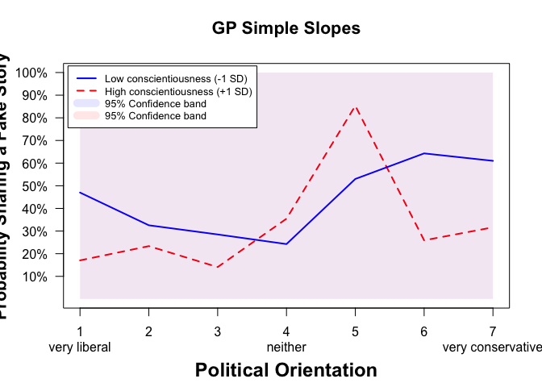

```r
  #GP simple slopes
      #LINES
       plot(1:7, brms.y.high[,1],type='l',ylim = c(0, 1),col='red',lty=2,lwd=2,ylab='',las=1,yaxt='n',xaxt='n',xlab='')
       points(1:7, brms.y.low[,1],type='l',col='blue',lwd=2)

      #Conf band
        polygon(c(1:7,7:1),as.vector(brms.y.high[, c(3,4)]), col=adjustcolor('red',.05), border=NA)
        polygon(c(1:7,7:1),as.vector(brms.y.low[, c(3,4)]), col=adjustcolor('blue',.05), border=NA)

      #X-axis
        axis(side=1,at=c(1:7))
        axis(side=1,at=c(1,4,7),line=1,c("very liberal","neither", "very conservative"),tick=FALSE)
        mtext(side=1,line=3.6,cex=1.5,font=2,"Political Orientation")

      #y=axis
        yt=seq(10,100,10)
        axis(side=2,at=yt/100,paste0(yt,"%"),las=1)
        mtext(side=2,line=3.5,cex=1.35,"Probability Sharing a Fake Story",font=2)

      #Header
        mtext(side=3,font=2,line=1.75,cex=1.35,'GP Simple Slopes')

      #legend
        col2=adjustcolor('blue',.1)
        col3=adjustcolor('red',.1)
        legend("topleft",col=c('blue','red',col2,col3),
            cex=.80,
            lty=c(1,2,1,1),lwd=c(2,2,10,10), inset=.01,
          legend=c("Low conscientiousness (-1 SD)",
                      "High conscientiousness (+1 SD)",
                      "95% Confidence band",
                      "95% Confidence band"))
```

- As `lscale` shows, the interaction does not seem linear. `brm` also estimated that low conscientious people tend to share more fake news but confidence intervals are totally overlapped, meaning that there is no really a difference. It also shows that there the conservatism’s moderation effect is not linear. Interestingly, people score 5 at conservatism scale tend to share more fake news based the GP simple slopes.

## References

- Lawson, M. A., & Kakkar, H. (2021). Of pandemics, politics, and personality: The role of conscientiousness and political ideology in the sharing of fake news. Journal of Experimental Psychology: General.
- Litzow, M. A., & Ciannelli, L. (2007). Oscillating trophic control induces community reorganization in a marine ecosystem. Ecology Letters, 10(12), 1124–1134. https://doi.org/10.1111/j.1461-0248.2007.01111.x
- Simonsohn, U. (2022). Interacting with curves: how to validly test and probe interactions in the real (nonlinear) world. *Working Paper*.
- Stenseth, N. C., Llope, M., Anadón, R., Ciannelli, L., Chan, K., Hjermann, D. Ø., Bagøien, E., & Ottersen, G. (2006). Seasonal plankton dynamics along a cross-shelf gradient. Proceedings of the Royal Society B: Biological Sciences, 273(1603), 2831–2838. https://doi.org/10.1098/rspb.2006.3658
- Zuur, A. F., E. N. Ieno, N. Walker, A. A. Saveliev, & G. M. Smith. (2009). Mixed effects models and extensions in ecology with R. Springer, New York, New York, USA